# Risk Factor Analysis

## Outcome Variable

**Outcome Variable:** ever_co

## Predictor Variables

**Intervention Variable:** mwtkg

**Adjustment Set:**

unadjusted

## Stratifying Variables

The analysis was stratified on these variable(s):

- agecat
- studyid
- country

## Data Summary

| agecat | studyid | country | mwtkg | ever_co | n_cell | n |
| --- | --- | --- | --- | --- | --- | --- |
| 0-24 months | iLiNS-Zinc | BURKINA FASO | >=58 kg | 0 | 868 | 3216 |
| 0-24 months | iLiNS-Zinc | BURKINA FASO | >=58 kg | 1 | 69 | 3216 |
| 0-24 months | iLiNS-Zinc | BURKINA FASO | <52 kg | 0 | 995 | 3216 |
| 0-24 months | iLiNS-Zinc | BURKINA FASO | <52 kg | 1 | 206 | 3216 |
| 0-24 months | iLiNS-Zinc | BURKINA FASO | [52-58) kg | 0 | 967 | 3216 |
| 0-24 months | iLiNS-Zinc | BURKINA FASO | [52-58) kg | 1 | 111 | 3216 |
| 0-24 months | JiVitA-3 | BANGLADESH | >=58 kg | 0 | 614 | 26892 |
| 0-24 months | JiVitA-3 | BANGLADESH | >=58 kg | 1 | 46 | 26892 |
| 0-24 months | JiVitA-3 | BANGLADESH | <52 kg | 0 | 22271 | 26892 |
| 0-24 months | JiVitA-3 | BANGLADESH | <52 kg | 1 | 2204 | 26892 |
| 0-24 months | JiVitA-3 | BANGLADESH | [52-58) kg | 0 | 1617 | 26892 |
| 0-24 months | JiVitA-3 | BANGLADESH | [52-58) kg | 1 | 140 | 26892 |
| 0-24 months | LCNI-5 | MALAWI | >=58 kg | 0 | 112 | 838 |
| 0-24 months | LCNI-5 | MALAWI | >=58 kg | 1 | 2 | 838 |
| 0-24 months | LCNI-5 | MALAWI | <52 kg | 0 | 475 | 838 |
| 0-24 months | LCNI-5 | MALAWI | <52 kg | 1 | 29 | 838 |
| 0-24 months | LCNI-5 | MALAWI | [52-58) kg | 0 | 209 | 838 |
| 0-24 months | LCNI-5 | MALAWI | [52-58) kg | 1 | 11 | 838 |
| 0-24 months | MAL-ED | BANGLADESH | >=58 kg | 0 | 45 | 254 |
| 0-24 months | MAL-ED | BANGLADESH | >=58 kg | 1 | 3 | 254 |
| 0-24 months | MAL-ED | BANGLADESH | <52 kg | 0 | 129 | 254 |
| 0-24 months | MAL-ED | BANGLADESH | <52 kg | 1 | 33 | 254 |
| 0-24 months | MAL-ED | BANGLADESH | [52-58) kg | 0 | 41 | 254 |
| 0-24 months | MAL-ED | BANGLADESH | [52-58) kg | 1 | 3 | 254 |
| 0-24 months | MAL-ED | BRAZIL | >=58 kg | 0 | 142 | 221 |
| 0-24 months | MAL-ED | BRAZIL | >=58 kg | 1 | 1 | 221 |
| 0-24 months | MAL-ED | BRAZIL | <52 kg | 0 | 42 | 221 |
| 0-24 months | MAL-ED | BRAZIL | <52 kg | 1 | 0 | 221 |
| 0-24 months | MAL-ED | BRAZIL | [52-58) kg | 0 | 35 | 221 |
| 0-24 months | MAL-ED | BRAZIL | [52-58) kg | 1 | 1 | 221 |

[output cut: 270 more lines]

The following strata were considered:

- agecat: 0-24 months, studyid: iLiNS-Zinc, country: BURKINA FASO
- agecat: 0-24 months, studyid: JiVitA-3, country: BANGLADESH
- agecat: 0-24 months, studyid: LCNI-5, country: MALAWI
- agecat: 0-24 months, studyid: MAL-ED, country: BANGLADESH
- agecat: 0-24 months, studyid: MAL-ED, country: BRAZIL
- agecat: 0-24 months, studyid: MAL-ED, country: INDIA
- agecat: 0-24 months, studyid: MAL-ED, country: NEPAL
- agecat: 0-24 months, studyid: MAL-ED, country: PERU
- agecat: 0-24 months, studyid: MAL-ED, country: SOUTH AFRICA
- agecat: 0-24 months, studyid: MAL-ED, country: TANZANIA, UNITED REPUBLIC OF
- agecat: 0-24 months, studyid: NIH-Birth, country: BANGLADESH
- agecat: 0-24 months, studyid: NIH-Crypto, country: BANGLADESH
- agecat: 0-24 months, studyid: PROBIT, country: BELARUS
- agecat: 0-24 months, studyid: PROVIDE, country: BANGLADESH
- agecat: 0-24 months, studyid: SAS-CompFeed, country: INDIA
- agecat: 0-24 months, studyid: TanzaniaChild2, country: TANZANIA, UNITED REPUBLIC OF
- agecat: 0-24 months, studyid: ZVITAMBO, country: ZIMBABWE
- agecat: 0-6 months, studyid: JiVitA-3, country: BANGLADESH
- agecat: 0-6 months, studyid: LCNI-5, country: MALAWI
- agecat: 0-6 months, studyid: MAL-ED, country: BANGLADESH
- agecat: 0-6 months, studyid: MAL-ED, country: BRAZIL
- agecat: 0-6 months, studyid: MAL-ED, country: INDIA
- agecat: 0-6 months, studyid: MAL-ED, country: NEPAL
- agecat: 0-6 months, studyid: MAL-ED, country: PERU
- agecat: 0-6 months, studyid: MAL-ED, country: SOUTH AFRICA
- agecat: 0-6 months, studyid: MAL-ED, country: TANZANIA, UNITED REPUBLIC OF
- agecat: 0-6 months, studyid: NIH-Birth, country: BANGLADESH
- agecat: 0-6 months, studyid: NIH-Crypto, country: BANGLADESH
- agecat: 0-6 months, studyid: PROBIT, country: BELARUS
- agecat: 0-6 months, studyid: PROVIDE, country: BANGLADESH
- agecat: 0-6 months, studyid: SAS-CompFeed, country: INDIA
- agecat: 0-6 months, studyid: TanzaniaChild2, country: TANZANIA, UNITED REPUBLIC OF
- agecat: 0-6 months, studyid: ZVITAMBO, country: ZIMBABWE
- agecat: 6-24 months, studyid: iLiNS-Zinc, country: BURKINA FASO
- agecat: 6-24 months, studyid: JiVitA-3, country: BANGLADESH
- agecat: 6-24 months, studyid: LCNI-5, country: MALAWI
- agecat: 6-24 months, studyid: MAL-ED, country: BANGLADESH
- agecat: 6-24 months, studyid: MAL-ED, country: BRAZIL
- agecat: 6-24 months, studyid: MAL-ED, country: INDIA
- agecat: 6-24 months, studyid: MAL-ED, country: NEPAL
- agecat: 6-24 months, studyid: MAL-ED, country: PERU
- agecat: 6-24 months, studyid: MAL-ED, country: SOUTH AFRICA
- agecat: 6-24 months, studyid: MAL-ED, country: TANZANIA, UNITED REPUBLIC OF
- agecat: 6-24 months, studyid: NIH-Birth, country: BANGLADESH
- agecat: 6-24 months, studyid: NIH-Crypto, country: BANGLADESH
- agecat: 6-24 months, studyid: PROBIT, country: BELARUS
- agecat: 6-24 months, studyid: PROVIDE, country: BANGLADESH
- agecat: 6-24 months, studyid: SAS-CompFeed, country: INDIA
- agecat: 6-24 months, studyid: TanzaniaChild2, country: TANZANIA, UNITED REPUBLIC OF
- agecat: 6-24 months, studyid: ZVITAMBO, country: ZIMBABWE

### Dropped Strata

Some strata were dropped due to rare outcomes:

- agecat: 0-24 months, studyid: LCNI-5, country: MALAWI
- agecat: 0-24 months, studyid: MAL-ED, country: BANGLADESH
- agecat: 0-24 months, studyid: MAL-ED, country: BRAZIL
- agecat: 0-24 months, studyid: MAL-ED, country: INDIA
- agecat: 0-24 months, studyid: MAL-ED, country: NEPAL
- agecat: 0-24 months, studyid: MAL-ED, country: PERU
- agecat: 0-24 months, studyid: MAL-ED, country: SOUTH AFRICA
- agecat: 0-24 months, studyid: MAL-ED, country: TANZANIA, UNITED REPUBLIC OF
- agecat: 0-24 months, studyid: PROBIT, country: BELARUS
- agecat: 0-6 months, studyid: LCNI-5, country: MALAWI
- agecat: 0-6 months, studyid: MAL-ED, country: BANGLADESH
- agecat: 0-6 months, studyid: MAL-ED, country: BRAZIL
- agecat: 0-6 months, studyid: MAL-ED, country: INDIA
- agecat: 0-6 months, studyid: MAL-ED, country: NEPAL
- agecat: 0-6 months, studyid: MAL-ED, country: PERU
- agecat: 0-6 months, studyid: MAL-ED, country: SOUTH AFRICA
- agecat: 0-6 months, studyid: MAL-ED, country: TANZANIA, UNITED REPUBLIC OF
- agecat: 0-6 months, studyid: NIH-Birth, country: BANGLADESH
- agecat: 0-6 months, studyid: NIH-Crypto, country: BANGLADESH
- agecat: 0-6 months, studyid: PROBIT, country: BELARUS
- agecat: 0-6 months, studyid: PROVIDE, country: BANGLADESH
- agecat: 0-6 months, studyid: SAS-CompFeed, country: INDIA
- agecat: 0-6 months, studyid: TanzaniaChild2, country: TANZANIA, UNITED REPUBLIC OF
- agecat: 6-24 months, studyid: LCNI-5, country: MALAWI
- agecat: 6-24 months, studyid: MAL-ED, country: BANGLADESH
- agecat: 6-24 months, studyid: MAL-ED, country: BRAZIL
- agecat: 6-24 months, studyid: MAL-ED, country: INDIA
- agecat: 6-24 months, studyid: MAL-ED, country: NEPAL
- agecat: 6-24 months, studyid: MAL-ED, country: PERU
- agecat: 6-24 months, studyid: MAL-ED, country: SOUTH AFRICA
- agecat: 6-24 months, studyid: MAL-ED, country: TANZANIA, UNITED REPUBLIC OF
- agecat: 6-24 months, studyid: PROBIT, country: BELARUS
- agecat: 6-24 months, studyid: PROVIDE, country: BANGLADESH

## Methods Detail

We’re interested in the causal parameters $E[Y_a]$ for all values of $a \in \mathcal{A}$. These parameters represent the mean outcome if, possibly contrary to fact, we intervened to set all units to have $A=a$. Under the randomization and positivity assumptions, these are identified by the statistical parameters $\psi_a=E_W[E_{Y|A,W}(Y|A=a,W)]$. In addition, we’re interested in the mean of $Y$, $E[Y]$ under no intervention (the observed mean). We will estimate these parameters by using SuperLearner to fit the relevant likelihood factors – $E_{Y|A,W}(Y|A=a,W)$ and $p(A=a|W)$, and then updating our likelihood fit using a joint TMLE.

For unadjusted analyses ($W=\{\}$), initial likelihoods were estimated using Lrnr_glm to estimate the simple $E(Y|A)$ and Lrnr_mean to estimate $p(A)$. For adjusted analyses, a small library containing Lrnr_glmnet, Lrnr_xgboost, and Lrnr_mean was used.

Having estimated these parameters, we will then use the delta method to estimate relative risks and attributable risks relative to a prespecified baseline level of $A$.

# Results Detail

## Results Plots

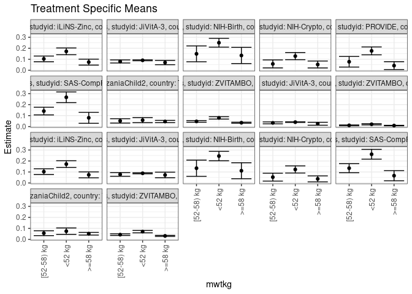

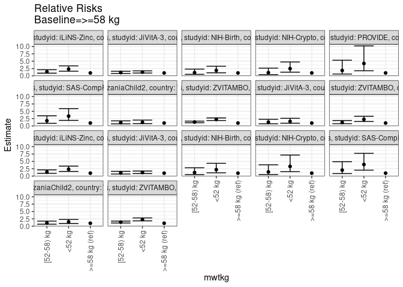

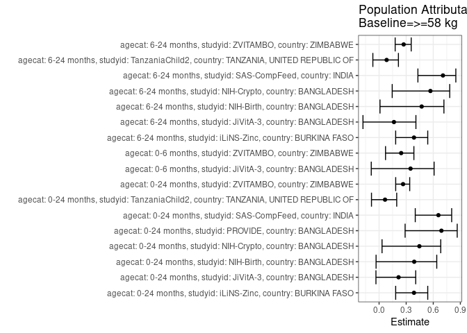

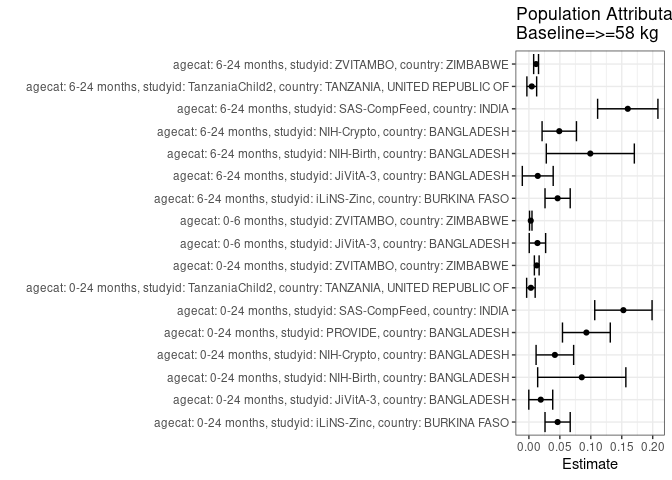

## Results Table

### Parameter: TSM

| agecat | studyid | country | intervention_level | baseline_level | estimate | ci_lower | ci_upper |
| --- | --- | --- | --- | --- | --- | --- | --- |
| 0-24 months | iLiNS-Zinc | BURKINA FASO | >=58 kg | NA | 0.0736393 | 0.0465479 | 0.1007306 |
| 0-24 months | iLiNS-Zinc | BURKINA FASO | <52 kg | NA | 0.1715237 | 0.1408221 | 0.2022254 |
| 0-24 months | iLiNS-Zinc | BURKINA FASO | [52-58) kg | NA | 0.1029685 | 0.0770844 | 0.1288525 |
| 0-24 months | JiVitA-3 | BANGLADESH | >=58 kg | NA | 0.0696970 | 0.0500429 | 0.0893510 |
| 0-24 months | JiVitA-3 | BANGLADESH | <52 kg | NA | 0.0900511 | 0.0860912 | 0.0940109 |
| 0-24 months | JiVitA-3 | BANGLADESH | [52-58) kg | NA | 0.0796813 | 0.0657033 | 0.0936593 |
| 0-24 months | NIH-Birth | BANGLADESH | >=58 kg | NA | 0.1341463 | 0.0603217 | 0.2079709 |
| 0-24 months | NIH-Birth | BANGLADESH | <52 kg | NA | 0.2500000 | 0.2098710 | 0.2901290 |
| 0-24 months | NIH-Birth | BANGLADESH | [52-58) kg | NA | 0.1489362 | 0.0769061 | 0.2209662 |
| 0-24 months | NIH-Crypto | BANGLADESH | >=58 kg | NA | 0.0520833 | 0.0206334 | 0.0835333 |
| 0-24 months | NIH-Crypto | BANGLADESH | <52 kg | NA | 0.1280788 | 0.0955514 | 0.1606063 |
| 0-24 months | NIH-Crypto | BANGLADESH | [52-58) kg | NA | 0.0573248 | 0.0209385 | 0.0937112 |
| 0-24 months | PROVIDE | BANGLADESH | >=58 kg | NA | 0.0416667 | 0.0058871 | 0.0774462 |
| 0-24 months | PROVIDE | BANGLADESH | <52 kg | NA | 0.1759259 | 0.1399941 | 0.2118577 |
| 0-24 months | PROVIDE | BANGLADESH | [52-58) kg | NA | 0.0769231 | 0.0286030 | 0.1252431 |
| 0-24 months | SAS-CompFeed | INDIA | >=58 kg | NA | 0.0796460 | 0.0298616 | 0.1294305 |
| 0-24 months | SAS-CompFeed | INDIA | <52 kg | NA | 0.2666084 | 0.2180473 | 0.3151695 |
| 0-24 months | SAS-CompFeed | INDIA | [52-58) kg | NA | 0.1410788 | 0.1062814 | 0.1758762 |
| 0-24 months | TanzaniaChild2 | TANZANIA, UNITED REPUBLIC OF | >=58 kg | NA | 0.0460705 | 0.0353733 | 0.0567676 |
| 0-24 months | TanzaniaChild2 | TANZANIA, UNITED REPUBLIC OF | <52 kg | NA | 0.0585242 | 0.0353120 | 0.0817364 |
| 0-24 months | TanzaniaChild2 | TANZANIA, UNITED REPUBLIC OF | [52-58) kg | NA | 0.0517598 | 0.0319982 | 0.0715215 |
| 0-24 months | ZVITAMBO | ZIMBABWE | >=58 kg | NA | 0.0350576 | 0.0303317 | 0.0397835 |
| 0-24 months | ZVITAMBO | ZIMBABWE | <52 kg | NA | 0.0792327 | 0.0684216 | 0.0900438 |
| 0-24 months | ZVITAMBO | ZIMBABWE | [52-58) kg | NA | 0.0471666 | 0.0395123 | 0.0548209 |
| 0-6 months | JiVitA-3 | BANGLADESH | >=58 kg | NA | 0.0258359 | 0.0125253 | 0.0391464 |
| 0-6 months | JiVitA-3 | BANGLADESH | <52 kg | NA | 0.0404463 | 0.0378126 | 0.0430800 |
| 0-6 months | JiVitA-3 | BANGLADESH | [52-58) kg | NA | 0.0337336 | 0.0249962 | 0.0424709 |
| 0-6 months | ZVITAMBO | ZIMBABWE | >=58 kg | NA | 0.0093136 | 0.0068410 | 0.0117862 |
| 0-6 months | ZVITAMBO | ZIMBABWE | <52 kg | NA | 0.0210172 | 0.0152529 | 0.0267815 |
| 0-6 months | ZVITAMBO | ZIMBABWE | [52-58) kg | NA | 0.0112436 | 0.0074289 | 0.0150583 |
| 6-24 months | iLiNS-Zinc | BURKINA FASO | >=58 kg | NA | 0.0736393 | 0.0465479 | 0.1007306 |
| 6-24 months | iLiNS-Zinc | BURKINA FASO | <52 kg | NA | 0.1715237 | 0.1408221 | 0.2022254 |
| 6-24 months | iLiNS-Zinc | BURKINA FASO | [52-58) kg | NA | 0.1029685 | 0.0770844 | 0.1288525 |
| 6-24 months | JiVitA-3 | BANGLADESH | >=58 kg | NA | 0.0725995 | 0.0470263 | 0.0981727 |
| 6-24 months | JiVitA-3 | BANGLADESH | <52 kg | NA | 0.0879949 | 0.0832557 | 0.0927341 |
| 6-24 months | JiVitA-3 | BANGLADESH | [52-58) kg | NA | 0.0777684 | 0.0610682 | 0.0944685 |
| 6-24 months | NIH-Birth | BANGLADESH | >=58 kg | NA | 0.1111111 | 0.0384528 | 0.1837694 |
| 6-24 months | NIH-Birth | BANGLADESH | <52 kg | NA | 0.2448454 | 0.2020204 | 0.2876703 |
| 6-24 months | NIH-Birth | BANGLADESH | [52-58) kg | NA | 0.1341463 | 0.0603128 | 0.2079799 |
| 6-24 months | NIH-Crypto | BANGLADESH | >=58 kg | NA | 0.0372340 | 0.0101510 | 0.0643171 |
| 6-24 months | NIH-Crypto | BANGLADESH | <52 kg | NA | 0.1227621 | 0.0902124 | 0.1553119 |
| 6-24 months | NIH-Crypto | BANGLADESH | [52-58) kg | NA | 0.0529801 | 0.0172287 | 0.0887316 |
| 6-24 months | SAS-CompFeed | INDIA | >=58 kg | NA | 0.0660377 | 0.0197187 | 0.1123567 |
| 6-24 months | SAS-CompFeed | INDIA | <52 kg | NA | 0.2611586 | 0.2166229 | 0.3056943 |
| 6-24 months | SAS-CompFeed | INDIA | [52-58) kg | NA | 0.1345291 | 0.0934755 | 0.1755828 |
| 6-24 months | TanzaniaChild2 | TANZANIA, UNITED REPUBLIC OF | >=58 kg | NA | 0.0509960 | 0.0388219 | 0.0631702 |
| 6-24 months | TanzaniaChild2 | TANZANIA, UNITED REPUBLIC OF | <52 kg | NA | 0.0741935 | 0.0450112 | 0.1033759 |
| 6-24 months | TanzaniaChild2 | TANZANIA, UNITED REPUBLIC OF | [52-58) kg | NA | 0.0558252 | 0.0336509 | 0.0779996 |
| 6-24 months | ZVITAMBO | ZIMBABWE | >=58 kg | NA | 0.0310757 | 0.0262753 | 0.0358761 |
| 6-24 months | ZVITAMBO | ZIMBABWE | <52 kg | NA | 0.0700847 | 0.0592324 | 0.0809370 |
| 6-24 months | ZVITAMBO | ZIMBABWE | [52-58) kg | NA | 0.0427581 | 0.0349753 | 0.0505409 |

### Parameter: E(Y)

| agecat | studyid | country | intervention_level | baseline_level | estimate | ci_lower | ci_upper |
| --- | --- | --- | --- | --- | --- | --- | --- |
| 0-24 months | iLiNS-Zinc | BURKINA FASO | NA | NA | 0.1200249 | 0.0999720 | 0.1400777 |
| 0-24 months | JiVitA-3 | BANGLADESH | NA | NA | 0.0888740 | 0.0849641 | 0.0927839 |
| 0-24 months | NIH-Birth | BANGLADESH | NA | NA | 0.2195513 | 0.1870467 | 0.2520558 |
| 0-24 months | NIH-Crypto | BANGLADESH | NA | NA | 0.0940397 | 0.0732057 | 0.1148737 |
| 0-24 months | PROVIDE | BANGLADESH | NA | NA | 0.1345291 | 0.1086533 | 0.1604050 |
| 0-24 months | SAS-CompFeed | INDIA | NA | NA | 0.2323097 | 0.1910149 | 0.2736046 |
| 0-24 months | TanzaniaChild2 | TANZANIA, UNITED REPUBLIC OF | NA | NA | 0.0493197 | 0.0405669 | 0.0580726 |
| 0-24 months | ZVITAMBO | ZIMBABWE | NA | NA | 0.0477427 | 0.0437874 | 0.0516981 |
| 0-6 months | JiVitA-3 | BANGLADESH | NA | NA | 0.0396491 | 0.0371433 | 0.0421548 |
| 0-6 months | ZVITAMBO | ZIMBABWE | NA | NA | 0.0123290 | 0.0102772 | 0.0143808 |
| 6-24 months | iLiNS-Zinc | BURKINA FASO | NA | NA | 0.1200249 | 0.0999720 | 0.1400777 |
| 6-24 months | JiVitA-3 | BANGLADESH | NA | NA | 0.0869137 | 0.0822507 | 0.0915768 |
| 6-24 months | NIH-Birth | BANGLADESH | NA | NA | 0.2103321 | 0.1759902 | 0.2446740 |
| 6-24 months | NIH-Crypto | BANGLADESH | NA | NA | 0.0863014 | 0.0659171 | 0.1066856 |
| 6-24 months | SAS-CompFeed | INDIA | NA | NA | 0.2257598 | 0.1896749 | 0.2618446 |
| 6-24 months | TanzaniaChild2 | TANZANIA, UNITED REPUBLIC OF | NA | NA | 0.0556399 | 0.0455330 | 0.0657467 |
| 6-24 months | ZVITAMBO | ZIMBABWE | NA | NA | 0.0427017 | 0.0386866 | 0.0467168 |

### Parameter: RR

| agecat | studyid | country | intervention_level | baseline_level | estimate | ci_lower | ci_upper |
| --- | --- | --- | --- | --- | --- | --- | --- |
| 0-24 months | iLiNS-Zinc | BURKINA FASO | >=58 kg | >=58 kg | 1.000000 | 1.0000000 | 1.000000 |
| 0-24 months | iLiNS-Zinc | BURKINA FASO | <52 kg | >=58 kg | 2.329242 | 1.5962639 | 3.398793 |
| 0-24 months | iLiNS-Zinc | BURKINA FASO | [52-58) kg | >=58 kg | 1.398282 | 0.9255029 | 2.112573 |
| 0-24 months | JiVitA-3 | BANGLADESH | >=58 kg | >=58 kg | 1.000000 | 1.0000000 | 1.000000 |
| 0-24 months | JiVitA-3 | BANGLADESH | <52 kg | >=58 kg | 1.292037 | 0.9735067 | 1.714790 |
| 0-24 months | JiVitA-3 | BANGLADESH | [52-58) kg | >=58 kg | 1.143253 | 0.8252319 | 1.583831 |
| 0-24 months | NIH-Birth | BANGLADESH | >=58 kg | >=58 kg | 1.000000 | 1.0000000 | 1.000000 |
| 0-24 months | NIH-Birth | BANGLADESH | <52 kg | >=58 kg | 1.863636 | 1.0505034 | 3.306168 |
| 0-24 months | NIH-Birth | BANGLADESH | [52-58) kg | >=58 kg | 1.110251 | 0.5336300 | 2.309949 |
| 0-24 months | NIH-Crypto | BANGLADESH | >=58 kg | >=58 kg | 1.000000 | 1.0000000 | 1.000000 |
| 0-24 months | NIH-Crypto | BANGLADESH | <52 kg | >=58 kg | 2.459113 | 1.2772751 | 4.734484 |
| 0-24 months | NIH-Crypto | BANGLADESH | [52-58) kg | >=58 kg | 1.100637 | 0.4583186 | 2.643143 |
| 0-24 months | PROVIDE | BANGLADESH | >=58 kg | >=58 kg | 1.000000 | 1.0000000 | 1.000000 |
| 0-24 months | PROVIDE | BANGLADESH | <52 kg | >=58 kg | 4.222222 | 1.7466447 | 10.206518 |
| 0-24 months | PROVIDE | BANGLADESH | [52-58) kg | >=58 kg | 1.846154 | 0.6370959 | 5.349719 |
| 0-24 months | SAS-CompFeed | INDIA | >=58 kg | >=58 kg | 1.000000 | 1.0000000 | 1.000000 |
| 0-24 months | SAS-CompFeed | INDIA | <52 kg | >=58 kg | 3.347417 | 1.8965196 | 5.908295 |
| 0-24 months | SAS-CompFeed | INDIA | [52-58) kg | >=58 kg | 1.771323 | 0.9040136 | 3.470729 |
| 0-24 months | TanzaniaChild2 | TANZANIA, UNITED REPUBLIC OF | >=58 kg | >=58 kg | 1.000000 | 1.0000000 | 1.000000 |
| 0-24 months | TanzaniaChild2 | TANZANIA, UNITED REPUBLIC OF | <52 kg | >=58 kg | 1.270319 | 0.8022590 | 2.011457 |
| 0-24 months | TanzaniaChild2 | TANZANIA, UNITED REPUBLIC OF | [52-58) kg | >=58 kg | 1.123493 | 0.7186273 | 1.756455 |
| 0-24 months | ZVITAMBO | ZIMBABWE | >=58 kg | >=58 kg | 1.000000 | 1.0000000 | 1.000000 |
| 0-24 months | ZVITAMBO | ZIMBABWE | <52 kg | >=58 kg | 2.260074 | 1.8656137 | 2.737937 |
| 0-24 months | ZVITAMBO | ZIMBABWE | [52-58) kg | >=58 kg | 1.345404 | 1.0895088 | 1.661403 |
| 0-6 months | JiVitA-3 | BANGLADESH | >=58 kg | >=58 kg | 1.000000 | 1.0000000 | 1.000000 |
| 0-6 months | JiVitA-3 | BANGLADESH | <52 kg | >=58 kg | 1.565510 | 0.9294667 | 2.636804 |
| 0-6 months | JiVitA-3 | BANGLADESH | [52-58) kg | >=58 kg | 1.305687 | 0.7471161 | 2.281867 |
| 0-6 months | ZVITAMBO | ZIMBABWE | >=58 kg | >=58 kg | 1.000000 | 1.0000000 | 1.000000 |
| 0-6 months | ZVITAMBO | ZIMBABWE | <52 kg | >=58 kg | 2.256628 | 1.5405831 | 3.305483 |
| 0-6 months | ZVITAMBO | ZIMBABWE | [52-58) kg | >=58 kg | 1.207231 | 0.7846842 | 1.857315 |
| 6-24 months | iLiNS-Zinc | BURKINA FASO | >=58 kg | >=58 kg | 1.000000 | 1.0000000 | 1.000000 |
| 6-24 months | iLiNS-Zinc | BURKINA FASO | <52 kg | >=58 kg | 2.329242 | 1.5962639 | 3.398793 |
| 6-24 months | iLiNS-Zinc | BURKINA FASO | [52-58) kg | >=58 kg | 1.398282 | 0.9255029 | 2.112573 |
| 6-24 months | JiVitA-3 | BANGLADESH | >=58 kg | >=58 kg | 1.000000 | 1.0000000 | 1.000000 |
| 6-24 months | JiVitA-3 | BANGLADESH | <52 kg | >=58 kg | 1.212059 | 0.8533440 | 1.721564 |
| 6-24 months | JiVitA-3 | BANGLADESH | [52-58) kg | >=58 kg | 1.071197 | 0.7068263 | 1.623401 |
| 6-24 months | NIH-Birth | BANGLADESH | >=58 kg | >=58 kg | 1.000000 | 1.0000000 | 1.000000 |
| 6-24 months | NIH-Birth | BANGLADESH | <52 kg | >=58 kg | 2.203608 | 1.1198381 | 4.336242 |
| 6-24 months | NIH-Birth | BANGLADESH | [52-58) kg | >=58 kg | 1.207317 | 0.5135934 | 2.838071 |
| 6-24 months | NIH-Crypto | BANGLADESH | >=58 kg | >=58 kg | 1.000000 | 1.0000000 | 1.000000 |
| 6-24 months | NIH-Crypto | BANGLADESH | <52 kg | >=58 kg | 3.297041 | 1.5201868 | 7.150750 |
| 6-24 months | NIH-Crypto | BANGLADESH | [52-58) kg | >=58 kg | 1.422895 | 0.5275590 | 3.837732 |
| 6-24 months | SAS-CompFeed | INDIA | >=58 kg | >=58 kg | 1.000000 | 1.0000000 | 1.000000 |
| 6-24 months | SAS-CompFeed | INDIA | <52 kg | >=58 kg | 3.954687 | 2.0214274 | 7.736885 |
| 6-24 months | SAS-CompFeed | INDIA | [52-58) kg | >=58 kg | 2.037156 | 0.8492977 | 4.886394 |
| 6-24 months | TanzaniaChild2 | TANZANIA, UNITED REPUBLIC OF | >=58 kg | >=58 kg | 1.000000 | 1.0000000 | 1.000000 |
| 6-24 months | TanzaniaChild2 | TANZANIA, UNITED REPUBLIC OF | <52 kg | >=58 kg | 1.454889 | 0.9183508 | 2.304895 |
| 6-24 months | TanzaniaChild2 | TANZANIA, UNITED REPUBLIC OF | [52-58) kg | >=58 kg | 1.094698 | 0.6886994 | 1.740039 |
| 6-24 months | ZVITAMBO | ZIMBABWE | >=58 kg | >=58 kg | 1.000000 | 1.0000000 | 1.000000 |
| 6-24 months | ZVITAMBO | ZIMBABWE | <52 kg | >=58 kg | 2.255289 | 1.8122268 | 2.806672 |
| 6-24 months | ZVITAMBO | ZIMBABWE | [52-58) kg | >=58 kg | 1.375933 | 1.0837200 | 1.746939 |

### Parameter: PAR

| agecat | studyid | country | intervention_level | baseline_level | estimate | ci_lower | ci_upper |
| --- | --- | --- | --- | --- | --- | --- | --- |
| 0-24 months | iLiNS-Zinc | BURKINA FASO | >=58 kg | NA | 0.0463856 | 0.0260451 | 0.0667261 |
| 0-24 months | JiVitA-3 | BANGLADESH | >=58 kg | NA | 0.0191770 | -0.0001418 | 0.0384959 |
| 0-24 months | NIH-Birth | BANGLADESH | >=58 kg | NA | 0.0854049 | 0.0141713 | 0.1566386 |
| 0-24 months | NIH-Crypto | BANGLADESH | >=58 kg | NA | 0.0419564 | 0.0116234 | 0.0722894 |
| 0-24 months | PROVIDE | BANGLADESH | >=58 kg | NA | 0.0928625 | 0.0542558 | 0.1314692 |
| 0-24 months | SAS-CompFeed | INDIA | >=58 kg | NA | 0.1526637 | 0.1063576 | 0.1989699 |
| 0-24 months | TanzaniaChild2 | TANZANIA, UNITED REPUBLIC OF | >=58 kg | NA | 0.0032493 | -0.0036371 | 0.0101356 |
| 0-24 months | ZVITAMBO | ZIMBABWE | >=58 kg | NA | 0.0126852 | 0.0088515 | 0.0165188 |
| 0-6 months | JiVitA-3 | BANGLADESH | >=58 kg | NA | 0.0138132 | 0.0005687 | 0.0270577 |
| 0-6 months | ZVITAMBO | ZIMBABWE | >=58 kg | NA | 0.0030155 | 0.0010296 | 0.0050013 |
| 6-24 months | iLiNS-Zinc | BURKINA FASO | >=58 kg | NA | 0.0463856 | 0.0260451 | 0.0667261 |
| 6-24 months | JiVitA-3 | BANGLADESH | >=58 kg | NA | 0.0143142 | -0.0106245 | 0.0392529 |
| 6-24 months | NIH-Birth | BANGLADESH | >=58 kg | NA | 0.0992210 | 0.0281155 | 0.1703265 |
| 6-24 months | NIH-Crypto | BANGLADESH | >=58 kg | NA | 0.0490673 | 0.0212967 | 0.0768380 |
| 6-24 months | SAS-CompFeed | INDIA | >=58 kg | NA | 0.1597220 | 0.1110245 | 0.2084196 |
| 6-24 months | TanzaniaChild2 | TANZANIA, UNITED REPUBLIC OF | >=58 kg | NA | 0.0046438 | -0.0032423 | 0.0125300 |
| 6-24 months | ZVITAMBO | ZIMBABWE | >=58 kg | NA | 0.0116260 | 0.0076997 | 0.0155523 |

### Parameter: PAF

| agecat | studyid | country | intervention_level | baseline_level | estimate | ci_lower | ci_upper |
| --- | --- | --- | --- | --- | --- | --- | --- |
| 0-24 months | iLiNS-Zinc | BURKINA FASO | >=58 kg | NA | 0.3864666 | 0.1837041 | 0.5388642 |
| 0-24 months | JiVitA-3 | BANGLADESH | >=58 kg | NA | 0.2157779 | -0.0347982 | 0.4056770 |
| 0-24 months | NIH-Birth | BANGLADESH | >=58 kg | NA | 0.3889977 | -0.0333865 | 0.6387375 |
| 0-24 months | NIH-Crypto | BANGLADESH | >=58 kg | NA | 0.4461561 | 0.0326597 | 0.6829006 |
| 0-24 months | PROVIDE | BANGLADESH | >=58 kg | NA | 0.6902778 | 0.2881910 | 0.8652337 |
| 0-24 months | SAS-CompFeed | INDIA | >=58 kg | NA | 0.6571559 | 0.4006051 | 0.8038988 |
| 0-24 months | TanzaniaChild2 | TANZANIA, UNITED REPUBLIC OF | >=58 kg | NA | 0.0658817 | -0.0842056 | 0.1951923 |
| 0-24 months | ZVITAMBO | ZIMBABWE | >=58 kg | NA | 0.2656985 | 0.1840139 | 0.3392060 |
| 0-6 months | JiVitA-3 | BANGLADESH | >=58 kg | NA | 0.3483864 | -0.0867005 | 0.6092757 |
| 0-6 months | ZVITAMBO | ZIMBABWE | >=58 kg | NA | 0.2445822 | 0.0713724 | 0.3854845 |
| 6-24 months | iLiNS-Zinc | BURKINA FASO | >=58 kg | NA | 0.3864666 | 0.1837041 | 0.5388642 |
| 6-24 months | JiVitA-3 | BANGLADESH | >=58 kg | NA | 0.1646943 | -0.1784315 | 0.4079115 |
| 6-24 months | NIH-Birth | BANGLADESH | >=58 kg | NA | 0.4717349 | 0.0102035 | 0.7180592 |
| 6-24 months | NIH-Crypto | BANGLADESH | >=58 kg | NA | 0.5685579 | 0.1453269 | 0.7822065 |
| 6-24 months | SAS-CompFeed | INDIA | >=58 kg | NA | 0.7074867 | 0.4298826 | 0.8499186 |
| 6-24 months | TanzaniaChild2 | TANZANIA, UNITED REPUBLIC OF | >=58 kg | NA | 0.0834625 | -0.0689736 | 0.2141612 |
| 6-24 months | ZVITAMBO | ZIMBABWE | >=58 kg | NA | 0.2722610 | 0.1780958 | 0.3556377 |